# HPMT 5214 - Midterm Exam

Evan Munro

3/09/2021

# **Prompt**

Note: Submit both your R code and word document under “Midterm” week in blackboard. Please submit your work before the finish time. Late penalty will be applied to late submissions.

```r
# loading all libraries that may be needed
library(readxl)
library(dplyr)
library(fpp2)
library(e1071)
library(MASS)
library(ggplot2)
```

## **1.**

#### Import the insurance cost data (5 points) in to RStudio then answer to the following questions:

```r
# preparing data
ins_data = read.csv("../Data/insurance.csv")
str(ins_data)
```

```
## 'data.frame':    1338 obs. of  7 variables:
##  $ age     : int  19 18 28 33 32 31 46 37 37 60 ...
##  $ sex     : chr  "female" "male" "male" "male" ...
##  $ bmi     : num  27.9 33.8 33 22.7 28.9 ...
##  $ children: int  0 1 3 0 0 0 1 3 2 0 ...
##  $ smoker  : chr  "yes" "no" "no" "no" ...
##  $ region  : chr  "southwest" "southeast" "southeast" "northwest" ...
##  $ charges : num  16885 1726 4449 21984 3867 ...
```

```r
ins_data$sex = as.factor(ins_data$sex)
ins_data$smoker = as.factor(ins_data$smoker)
ins_data$region = as.factor(ins_data$region)
summary(ins_data)
```

```
##       age            sex           bmi           children     smoker
##  Min.   :18.00   female:662   Min.   :15.96   Min.   :0.000   no :1064
##  1st Qu.:27.00   male  :676   1st Qu.:26.30   1st Qu.:0.000   yes: 274
##  Median :39.00                Median :30.40   Median :1.000
##  Mean   :39.21                Mean   :30.66   Mean   :1.095
##  3rd Qu.:51.00                3rd Qu.:34.69   3rd Qu.:2.000
##  Max.   :64.00                Max.   :53.13   Max.   :5.000
##        region       charges
##  northeast:324   Min.   : 1122
##  northwest:325   1st Qu.: 4740
##  southeast:364   Median : 9382
##  southwest:325   Mean   :13270
##                  3rd Qu.:16640
##                  Max.   :63770
```

### **a)**

#### How many missing values are there in the data [Use the appropriate function in R to obtain the number of missing values in the data]?

```r
sum(is.na(ins_data))
```

```
## [1] 0
```

There are 0 missing values in the data.

### **b)**

#### Create a scatter plot of “charges” versus “age”.

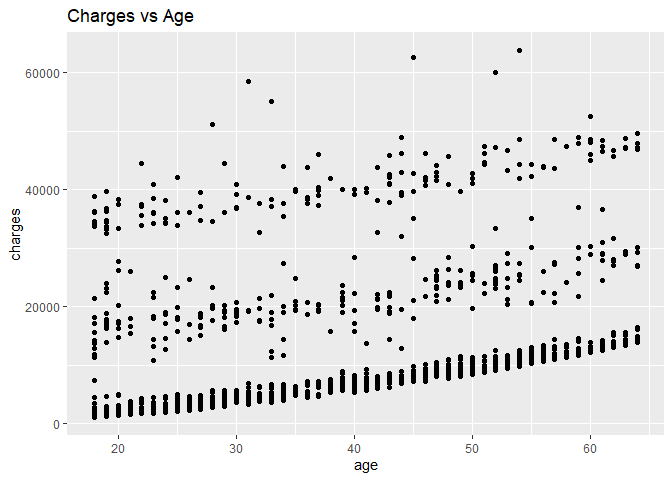

```r
ggplot(ins_data, aes(age, charges)) +
  geom_point() +
  ggtitle("Charges vs Age")
```

### **c)**

#### Create a scatter plot of “charges” versus “age” and modify the color of the points based on the value of “smoker” variable. How do you interpret this plot?

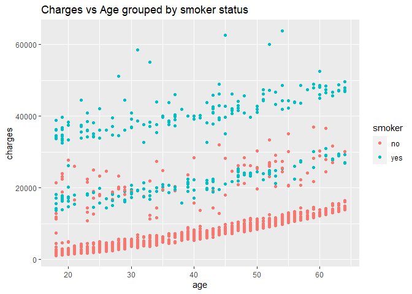

```r
ggplot(ins_data, aes(age, charges, group = smoker, color = smoker)) +
  geom_point() +
  ggtitle("Charges vs Age grouped by smoker status")
```

Based on this plot, it appears that smokers on average have higher charges than non-smokers when age is held constant, and charges increase as age increases.

### **d)**

#### Fit a multiple regression model to predict “charges” using all of the variables in the data.

```r
ins_lm = lm(charges ~ ., data = ins_data)
```

### **e)**

#### Provide an interpretation of each coefficient in the model. Be careful—some of the variables in the model are qualitative!

```r
ins_lm
```

```
##
## Call:
## lm(formula = charges ~ ., data = ins_data)
##
## Coefficients:
##     (Intercept)              age          sexmale              bmi
##        -11938.5            256.9           -131.3            339.2
##        children        smokeryes  regionnorthwest  regionsoutheast
##           475.5          23848.5           -353.0          -1035.0
## regionsouthwest
##          -960.1
```

### **f)**

#### Write out the model in equation form, being careful to handle the qualitative variables properly.

$Charges = -11938.5 + 256.9(X_{Age}) - 131.30(X_{SexMale}) + 339.20(X_{BMI}) + 475.50(X_{Children}) + 23848.50(X_{SmokerYes}) - 353.00(X_{RegionNW}) - 1035.0(X_{RegionSE}) - 960.10(X_{RegionSW})+ \epsilon$

### **g)**

#### For which of the predictors can you reject the null hypothesis $H_0:\beta_j= 0$?

```r
summary(ins_lm)
```

```
##
## Call:
## lm(formula = charges ~ ., data = ins_data)
##
## Residuals:
##      Min       1Q   Median       3Q      Max
## -11304.9  -2848.1   -982.1   1393.9  29992.8
##
## Coefficients:
##                 Estimate Std. Error t value Pr(>|t|)
## (Intercept)     -11938.5      987.8 -12.086  < 2e-16 ***
## age                256.9       11.9  21.587  < 2e-16 ***
## sexmale           -131.3      332.9  -0.394 0.693348
## bmi                339.2       28.6  11.860  < 2e-16 ***
## children           475.5      137.8   3.451 0.000577 ***
## smokeryes        23848.5      413.1  57.723  < 2e-16 ***
## regionnorthwest   -353.0      476.3  -0.741 0.458769
## regionsoutheast  -1035.0      478.7  -2.162 0.030782 *
## regionsouthwest   -960.0      477.9  -2.009 0.044765 *
## ---
## Signif. codes:  0 '***' 0.001 '**' 0.01 '*' 0.05 '.' 0.1 ' ' 1
##
## Residual standard error: 6062 on 1329 degrees of freedom
## Multiple R-squared:  0.7509, Adjusted R-squared:  0.7494
## F-statistic: 500.8 on 8 and 1329 DF,  p-value: < 2.2e-16
```

The null hypothesis can be rejected for age, bmi, children, smoker(yes), region(SE), and region(SW) because their p-values are all less than 0.05.

### **h)**

#### How well does the models in (d) fit the data?

It looks like the model fits the data pretty well as indicated by the adjusted R-squared value of 0.7494, which can be interpreted by saying the model can explain roughly 75% of the variability in insurance charges.

However, the residual plots below show that there is heteroscedasticity (residuals vs fitted plot) and that the data is not normally distributed (Q-Q plot), so the model needs to improved to better fit the data.

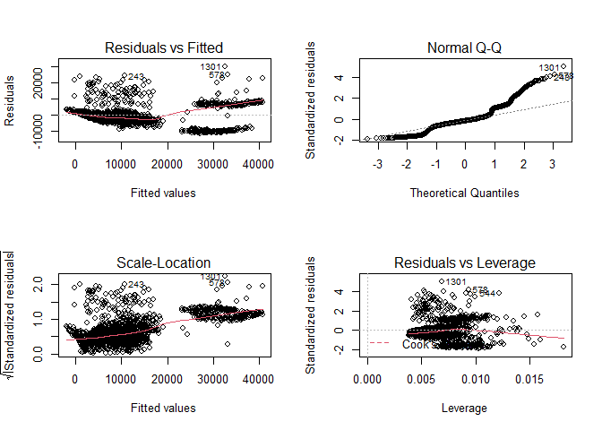

```r
par(mfrow = c(2,2))
plot(ins_lm)
```

## **2.**

#### A data set named “weekly flu rates” is given to you. This data shows the weekly percent of influenza positive tests collected from public health laboratories in the US between 2015 and 2019. Import this data to RStudio (5 points) then answer to the following questions:

```r
# preparing data
flu_data = read_excel("../Data/weekly flu rates.xlsx")
```

### **a)**

#### After importing the data into RStudio, produce a numerical summary of each variable in the dataset.

```r
summary(flu_data)
```

```
##       YEAR           WEEK       PERCENTPOSITIVE
##  Min.   :2015   Min.   : 1.00   Min.   : 0.7643
##  1st Qu.:2016   1st Qu.:12.00   1st Qu.: 1.6993
##  Median :2017   Median :26.00   Median : 4.1652
##  Mean   :2017   Mean   :26.31   Mean   : 8.5388
##  3rd Qu.:2018   3rd Qu.:41.00   3rd Qu.:15.3280
##  Max.   :2019   Max.   :52.00   Max.   :27.3698
```

### **b)**

#### Create a weekly time series object [Note: include all years from 2015 to 2019].

```r
flu_ts = ts(flu_data$PERCENTPOSITIVE, start=c(2015, 40), frequency=52)
```

### **c)**

#### Create a weekly seasonal plot for the time series that you created in section (b). When do outbreaks usually occur?

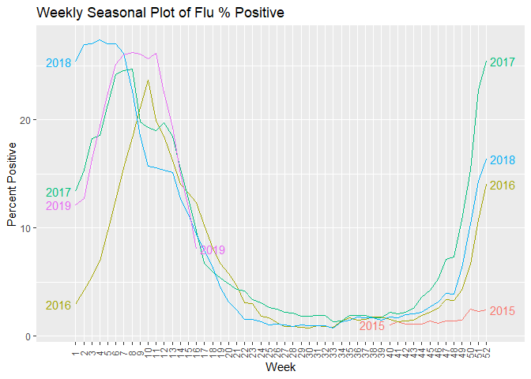

```r
weeks = seq(2, 52, 2)
ggseasonplot(flu_ts, year.labels=TRUE, year.labels.left=TRUE) +
  ggtitle("Weekly Seasonal Plot of Flu % Positive") +
  ylab("Percent Positive") +
  theme(axis.text.x = element_text(angle = 90, vjust = 0.4))
```

It appears that outbreaks usually occur in the winter starting around December(week 48) and stopping around May(week 18).

### **d)**

#### Split the data into training and testing. Put the weekly data starting from week 40 in 2015 to the end of 2018 in the training set and put the rest of the data in the testing set.

```r
trainSet = window(flu_ts, start = c(2015, 40), end = c(2018, 52), frequency = 52)
testSet = window(flu_ts, start = c(2019, 1), frequency = 52)
```

### **e)**

#### Use Average, Naïve and Seasonal Naïve forecasting methods to forecast the testing set.

```r
str(testSet)
```

```
##  Time-Series [1:16] from 2019 to 2019: 12.2 12.7 16.3 19.4 22.5 ...
```

```r
avgForc = meanf(trainSet, h = 16)
naiveForc = naive(trainSet, h = 16)
snaiveForc = snaive(trainSet, h = 16)
```

### **f)**

#### Develop the autoplot for the previous step.

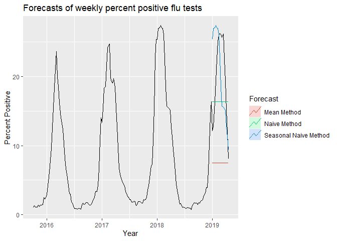

```r
autoplot(flu_ts) +
  autolayer(avgForc, series = "Mean Method", PI = FALSE) +
  autolayer(naiveForc, series = "Naive Method", PI = FALSE) +
  autolayer(snaiveForc, series = "Seasonal Naive Method", PI = FALSE) +
  ggtitle("Forecasts of weekly percent positive flu tests") +
  xlab("Year") +
  ylab("Percent Positive") +
  guides(colour = guide_legend(title = "Forecast"))
```

### **g)**

#### Calculate accuracy of the methods used in Section (e) using the testing set. Which method is the best?

```r
accuracy(avgForc, testSet)
```

```
##                        ME      RMSE       MAE        MPE      MAPE     MASE
## Training set 3.230127e-16  7.864769  6.630411 -196.01138 230.57321 2.221677
## Test set     1.222815e+01 13.629294 12.228154   56.98413  56.98413 4.097334
##                   ACF1 Theil's U
## Training set 0.9733630        NA
## Test set     0.7420026  3.852761
```

```r
accuracy(naiveForc, testSet)
```

```
##                      ME     RMSE      MAE        MPE    MAPE      MASE
## Training set 0.09129952 1.611289 1.004834 -0.3673617 15.2902 0.3366934
## Test set     3.31529437 6.871760 6.075168  5.7366906 32.3909 2.0356295
##                   ACF1 Theil's U
## Training set 0.6826401        NA
## Test set     0.7420026  2.090292
```

```r
accuracy(snaiveForc, testSet)
```

```
##                      ME    RMSE      MAE        MPE     MAPE     MASE      ACF1
## Training set  1.2311574 4.60637 2.984417  -1.235696 44.29424 1.000000 0.9214016
## Test set     -0.4809388 7.64792 6.252426 -10.833198 35.48351 2.095024 0.8545220
##              Theil's U
## Training set        NA
## Test set      2.722046
```

The naive method is the best according to it producing the lowest test set MAPE, MASE, MAE, and RMSE.